# C_Chat_project

Tu hao wei

2018/11/14

# 介紹

使用並修改老師的程式，對PTT的C_Chat版分析，時間從2018-10-9凌晨左右至2018-10-17中午。

下面幾篇文章可能影響結果

```
作者mistel (Mistel)
看板C_Chat
標題[討論] 化學系真的會在實驗室拿燒杯煮咖啡嗎？
時間Sun Oct 14 12:01:37 2018
發信站: 批踢踢實業坊(ptt.cc), 來自: 223.137.97.110
文章網址: https://www.ptt.cc/bbs/C_Chat/M.1539489699.A.933.html
```

# 開始

### 1.載入packages

```r
library(bitops)
library(httr)
library(RCurl)
library(XML)
library(tm)
library(NLP)
library(tmcn)
```

```r
library(jiebaRD)
library(jiebaR)
library(RColorBrewer)
library(cluster)
library(pvclust)
library(xtable)
#library(limma)
library(plyr)
library(ggplot2)
library(car)
library(lattice)
```

### 2.PTT爬蟲，將需要的資料抓下來，並按照日期分成不同檔案

```r
#get the website url of all the article from every pages
from <- 17412 # 2018-10-10
to   <- 17550 # 2018-10-17
prefix = "https://www.ptt.cc/bbs/C_Chat/index"
data <- list()
for( id in c(from:to) )
{
  url  <- paste0( prefix, as.character(id), ".html" )
  html <- htmlParse( GET(url) )
  url.list <- xpathSApply( html, "//div[@class='title']/a[@href]", xmlAttrs )
  data <- rbind( data, as.matrix(paste('https://www.ptt.cc', url.list, sep='')) )
}
data <- unlist(data)
head(data)

#get all the context, and sort them by date
library(dplyr)
getdoc <- function(url)
{
  html <- htmlParse( getURL(url) )
  doc  <- xpathSApply( html, "//div[@id='main-content']", xmlValue )
  time <- xpathSApply( html, "//*[@id='main-content']/div[4]/span[2]", xmlValue )
  temp <- gsub( "  ", " 0", unlist(time) )
  part <- strsplit( temp, split=" ", fixed=T )
  #part form like -> "Tue"      "Oct"      "09"       "23:43:27" "2018"
  date <- part[[1]][3]
  day <- part[[1]][1]
  #print(date and dat)
  name <- paste0('./DATA/', date, "__", day, ".txt")
  write(doc, name, append = TRUE)
}
test.data <- data[1:1058]
sapply(test.data, getdoc)
#structure of data[1059] is not as same as the others
#https://www.ptt.cc/bbs/C_Chat/M.1539346213.A.3D3.html
test.data = data[1060:1437]
sapply(test.data, getdoc)

#structure of data[1438] is not as same as the others
#https://www.ptt.cc/bbs/C_Chat/M.1539438107.A.869.html
test.data <- data[1439:2724]
sapply(test.data, getdoc)

#cannot opent data[2161]
#https://www.ptt.cc/bbs/C_Chat/M.1539603620.A.E09.html
test.data <- data[2162:2724]
sapply(test.data, getdoc)

#stop at data[2311]
#https://www.ptt.cc/bbs/C_Chat/M.1539645748.A.C76.html
test.data <- data[2311:2724]
sapply(test.data, getdoc)

#stop at data[2724]
#https://www.ptt.cc/bbs/C_Chat/M.1539747042.A.B75.html
```

### 3.建立Corpus並清洗

```r
#cleaning and add new words
d.corpus <- Corpus( DirSource("./DATA") )
toSpace <- content_transformer(function(x, pattern) {
  return (gsub(pattern, " ", x))
})

d.corpus <- tm_map(d.corpus, toSpace, "　")
d.corpus <- tm_map(d.corpus, toSpace, "︳")
d.corpus <- tm_map(d.corpus, toSpace, "・")
d.corpus <- tm_map(d.corpus, toSpace, "ー")
d.corpus <- tm_map(d.corpus, toSpace, "小說")
d.corpus <- tm_map(d.corpus, toSpace, "覺得")
d.corpus <- tm_map(d.corpus, toSpace, "可以")
d.corpus <- tm_map(d.corpus, toSpace, "沒有")
d.corpus <- tm_map(d.corpus, toSpace, "就是")
d.corpus <- tm_map(d.corpus, toSpace, "標題")
d.corpus <- tm_map(d.corpus, toSpace, "編輯")
d.corpus <- tm_map(d.corpus, toSpace, "發信站")
d.corpus <- tm_map(d.corpus, toSpace, "批踢踢實業坊")
d.corpus <- tm_map(d.corpus, toSpace, "自己")
d.corpus <- tm_map(d.corpus, toSpace, "應該")
d.corpus <- tm_map(d.corpus, toSpace, "知道")
d.corpus <- tm_map(d.corpus, toSpace, "真的")
d.corpus <- tm_map(d.corpus, toSpace, "不會")
d.corpus <- tm_map(d.corpus, toSpace, "動畫")
d.corpus <- tm_map(d.corpus, toSpace, "不是")
d.corpus <- tm_map(d.corpus, toSpace, "只是")
d.corpus <- tm_map(d.corpus, toSpace, "所以")
d.corpus <- tm_map(d.corpus, toSpace, "不會")

d.corpus <- tm_map(d.corpus, toSpace, "[a-zA-Z]")

d.corpus <- tm_map(d.corpus, removePunctuation)
d.corpus <- tm_map(d.corpus, removeNumbers)
```

### 4.建立詞庫(2018秋季動畫詞庫)

```r
mixseg = worker()
new_user_word(mixseg,'哥布林',"n")
```

```
## [1] TRUE
```

```r
new_user_word(mixseg,'哥殺',"n")
```

```
## [1] TRUE
```

```r
new_user_word(mixseg,'哥布林殺手',"n")
```

```
## [1] TRUE
```

```r
new_user_word(mixseg,'魔禁',"n")
```

```
## [1] TRUE
```

```r
new_user_word(mixseg,'魔法禁書目錄',"n")
```

```
## [1] TRUE
```

```r
new_user_word(mixseg,'提拉米斯',"n")
```

```
## [1] TRUE
```

```r
new_user_word(mixseg,'魔導少年',"n")
```

```
## [1] TRUE
```

```r
new_user_word(mixseg,'妖尾',"n")
```

```
## [1] TRUE
```

```r
new_user_word(mixseg,'妖精的尾巴',"n")
```

```
## [1] TRUE
```

```r
new_user_word(mixseg,'電光超人',"n")
```

```
## [1] TRUE
```

```r
new_user_word(mixseg,'繽紛世界',"n")
```

```
## [1] TRUE
```

```r
new_user_word(mixseg,'青春豬頭',"n")
```

```
## [1] TRUE
```

```r
new_user_word(mixseg,'終將成為妳',"n")
```

```
## [1] TRUE
```

```r
new_user_word(mixseg,'莉茲與青鳥',"n")
```

```
## [1] TRUE
```

```r
new_user_word(mixseg,'逆轉裁判',"n")
```

```
## [1] TRUE
```

```r
new_user_word(mixseg,'弦音',"n")
```

```
## [1] TRUE
```

```r
new_user_word(mixseg,'佐賀偶像',"n")
```

```
## [1] TRUE
```

```r
new_user_word(mixseg,'刀劍神域',"n")
```

```
## [1] TRUE
```

### 5.進行斷詞，並依照日期建立文本矩陣 TermDocumentMatrix

```r
jieba_tokenizer = function(d)
{
  unlist( segment(d[[1]], mixseg) )
}
seg = lapply(d.corpus, jieba_tokenizer)

count_token = function(d)
{
  as.data.frame(table(d))
}
tokens = lapply(seg, count_token)

n = length(seg)
TDM = tokens[[1]]
colNames <- names(seg)
colNames <- gsub(".txt", "", colNames)
for( id in c(2:n) )
{
  TDM = merge(TDM, tokens[[id]], by="d", all = TRUE)
  names(TDM) = c('d', colNames[1:id])
}
TDM[is.na(TDM)] <- 0
#take out
TDM$d <- as.character(TDM$d)
TDM <- TDM[nchar(TDM$d)>1,]#去除字數是1的詞
library(knitr)
kable(head(TDM))
```

|  | d | 10__Wed | 11__Thu | 12__Fri | 13__Sat | 14__Sun | 15__Mon | 16__Tue |
| --- | --- | --- | --- | --- | --- | --- | --- | --- |
| 16 | 阿阿阿 | 2 | 1 | 5 | 2 | 3 | 0 | 1 |
| 17 | 阿阿阿阿看 | 1 | 0 | 0 | 0 | 0 | 0 | 0 |
| 18 | 阿邦式 | 3 | 0 | 0 | 0 | 0 | 0 | 0 |
| 19 | 阿北 | 1 | 0 | 3 | 2 | 0 | 0 | 0 |
| 20 | 阿比 | 3 | 0 | 1 | 0 | 1 | 2 | 0 |
| 21 | 阿扁 | 3 | 0 | 0 | 0 | 0 | 3 | 4 |

```r
kable(tail(TDM))
```

|  | d | 10__Wed | 11__Thu | 12__Fri | 13__Sat | 14__Sun | 15__Mon | 16__Tue |
| --- | --- | --- | --- | --- | --- | --- | --- | --- |
| 85029 | 做屬 | 0 | 0 | 0 | 0 | 0 | 0 | 1 |
| 85030 | 做星 | 0 | 0 | 0 | 0 | 0 | 0 | 2 |
| 85031 | 做一套 | 0 | 0 | 0 | 0 | 0 | 0 | 1 |
| 85032 | 做原 | 0 | 0 | 0 | 0 | 0 | 0 | 1 |
| 85033 | 做志工 | 0 | 0 | 0 | 0 | 0 | 0 | 1 |
| 85034 | 做種 | 0 | 0 | 0 | 0 | 0 | 0 | 1 |

### 6.TDM -> TF-IDF

```r
tf <- apply(as.matrix(TDM[,2:(n+1)]), 2, sum)

library(Matrix)
idfCal <- function(word_doc)
{
  log2( n / nnzero(word_doc) )
}
idf <- apply(as.matrix(TDM[,2:(n+1)]), 1, idfCal)

doc.tfidf <- TDM

tempY = matrix(rep(c(as.matrix(tf)), each = length(idf)), nrow = length(idf))
tempX = matrix(rep(c(as.matrix(idf)), each = length(tf)), ncol = length(tf), byrow = TRUE)
doc.tfidf[,2:(n+1)] <- (doc.tfidf[,2:(n+1)] / tempY) * tempX

# goblinID <- as.character(match("哥布林",doc.tfidf))
# goblinslayerID <- as.character(match("哥布林殺手",doc.tfidf))

stopLine = rowSums(doc.tfidf[,2:(n+1)])
stopLine["6050"] <- 1 #哥布林
stopLine["6051"] <- 1 #哥布林殺手
delID = which(stopLine == 0)


kable(head(doc.tfidf[delID,1]))
```

| x |
| --- |
| 阿福 |
| 阿克 |
| 阿拉 |
| 阿斯 |
| 阿宅 |
| 啊啊啊 |

```r
kable(tail(doc.tfidf[delID,1]))
```

| x |
| --- |
| 做到 |
| 做法 |
| 做個 |
| 做過 |
| 做好 |
| 做事 |

```r
TDM = TDM[-delID,]
doc.tfidf = doc.tfidf[-delID,]
```

“哥布林”和“哥布林殺手“兩詞每天都有出現在討論中，所以TF-IDF運算時會把他們去除。 但這邊將他們特別留下，的原因是他們都是和此季動畫有關聯的詞語。

### 7.取得關鍵字 (tfidf)

```r
TopWords.tfidf = data.frame()
for( id in c(1:n) )
{
  dayMax = order(doc.tfidf[,id+1], decreasing = TRUE)
  showResult = t(as.data.frame(doc.tfidf[dayMax[1:5],1]))
  TopWords.tfidf = rbind(TopWords.tfidf, showResult)
}
rownames(TopWords.tfidf) = colnames(doc.tfidf)[2:(n+1)]
TopWords.tfidf <- TopWords.tfidf[1:7,]
TopWords.tfidf = droplevels(TopWords.tfidf)
kable(TopWords.tfidf)
```

|  | V1 | V2 | V3 | V4 | V5 |
| --- | --- | --- | --- | --- | --- |
| 10__Wed | 剖腹 | 剖腹產 | 單眼 | 千晶 | 生日快樂 |
| 11__Thu | 貓箱 | 衰變 | 量子 | 梓川楓 | 凱特 |
| 12__Fri | 瑞依 | 老五 | 春希 | 控制器 | 音樂會 |
| 13__Sat | 會陰 | 奈威 | 烏龍茶 | 竹中 | 靜香 |
| 14__Sun | 燒杯 | 化學系 | 諡號 | 會陰 | 廟號 |
| 15__Mon | 肇事 | 倭寇 | 拉加 | 拖出去 | 遊了 |
| 16__Tue | 周瑜 | 養狗 | 釋疑 | 青嵐 | 福爾摩斯 |

因為剛剛提過的“哥布林”和“哥布林殺手”兩詞所造成的影響， 以TDM和TF-IDF的矩陣所做出的關鍵字會略有不同。

### 7.1取得關鍵字 (TDM)

```r
TopWords.TDM = data.frame()
for( id in c(1:n) )
{
  dayMax = order(TDM[,id+1], decreasing = TRUE)
  showResult = t(as.data.frame(TDM[dayMax[1:5],1]))
  TopWords.TDM = rbind(TopWords.TDM, showResult)
}
rownames(TopWords.TDM) = colnames(TDM)[2:(n+1)]
TopWords.TDM <- TopWords.TDM[1:7,]
TopWords.TDM = droplevels(TopWords.TDM)
kable(TopWords.TDM)
```

|  | V1 | V2 | V3 | V4 | V5 |
| --- | --- | --- | --- | --- | --- |
| 10__Wed | 哥布林 | 生日快樂 | 當哥 | 剖腹 | 剖腹產 |
| 11__Thu | 哥布林 | 薛丁格 | 櫻島 | 貓箱 | 觀測 |
| 12__Fri | 哥布林 | 雪菜 | 神魔 | 蟻王 | 瑞依 |
| 13__Sat | 哥布林 | 大雄 | 會陰 | 火把 | 蟻王 |
| 14__Sun | 哥布林 | 實驗室 | 燒杯 | 聖壁 | 會陰 |
| 15__Mon | 哥布林 | 坦克 | 碎片 | 倭寇 | 火鍋 |
| 16__Tue | 哥布林 | 農民 | 棍棒 | 五星 | 佐賀 |

以TDM做出的關鍵字明顯可以看出“哥布林”盤據了許多位置。

### 8.用取得的關鍵字將TDM視覺化

```r
AllTop = as.data.frame( table(as.matrix(TopWords.tfidf)) )
AllTop = AllTop[order(AllTop$Freq, decreasing = TRUE),]

kable(head(AllTop))
```

|  | Var1 | Freq |
| --- | --- | --- |
| 5 | 會陰 | 2 |
| 1 | 春希 | 1 |
| 2 | 單眼 | 1 |
| 3 | 福爾摩斯 | 1 |
| 4 | 化學系 | 1 |
| 6 | 靜香 | 1 |

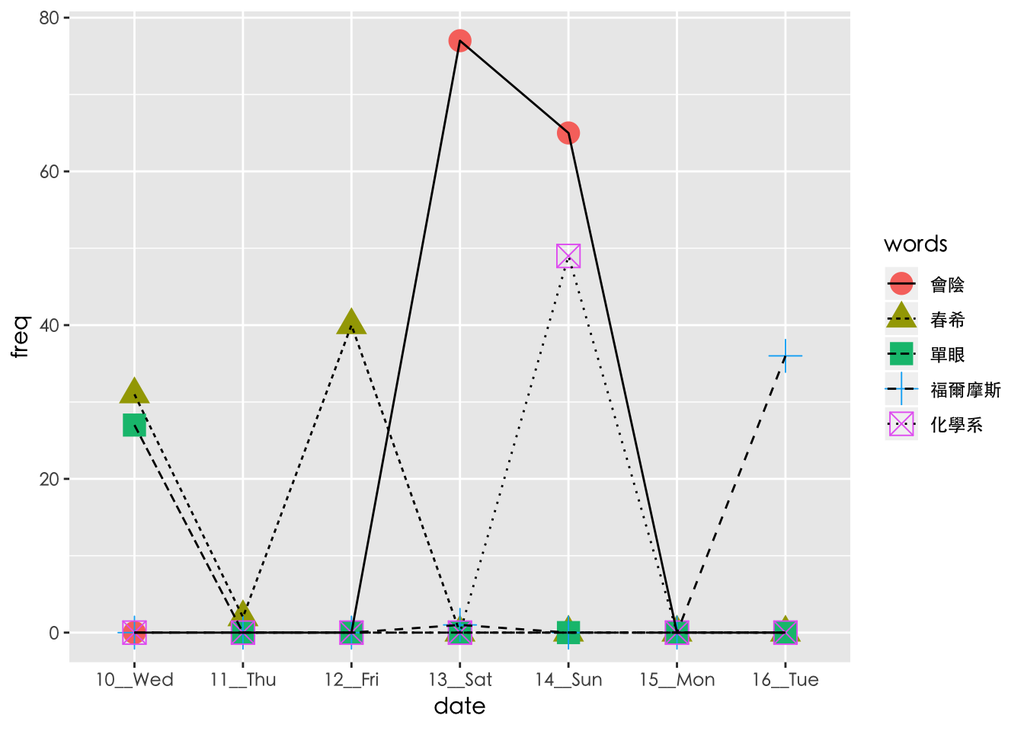

```r
TopNo = 5
tempGraph = data.frame()
for( t in c(1:TopNo) )
{
  word = matrix( rep(c(as.matrix(AllTop$Var1[t])), each = n), nrow = n )
  temp = cbind( colnames(doc.tfidf)[2:(n+1)], t(TDM[which(TDM$d == AllTop$Var1[t]), 2:(n+1)]), word )
  colnames(temp) = c("date", "freq", "words")
  tempGraph = rbind(tempGraph, temp)
  names(tempGraph) = c("date", "freq", "words")
}

library(ggplot2)
library(varhandle)
tempGraph$freq = unfactor(tempGraph$freq)
ggplot(tempGraph, aes(date, freq)) +
  geom_point(aes(color = words, shape = words), size = 5) +
  geom_line(aes(group = words, linetype = words)) +
  theme(text = element_text(family = "黑體-繁 中黑"))
```

```r
kable(tail(AllTop))
```

|  | Var1 | Freq |
| --- | --- | --- |
| 29 | 音樂會 | 1 |
| 30 | 遊了 | 1 |
| 31 | 肇事 | 1 |
| 32 | 周瑜 | 1 |
| 33 | 竹中 | 1 |
| 34 | 梓川楓 | 1 |

以下分別討論圖片上的五個詞語

1.會陰 https://www.ptt.cc/bbs/C_Chat/M.1539521892.A.1C4.html https://www.ptt.cc/bbs/C_Chat/M.1539439827.A.187.html 原因是上面兩篇動畫哥布林殺手衍生出的安價文[註8-1]。 底下網友的安價內容不斷出現會陰，使得此詞彙出現頻率變高。

2.春希 https://www.ptt.cc/bbs/C_Chat/M.1539301985.A.646.html 春希兩字是白色相簿2的男主角，10/12有一篇關於白色相簿二的心得， 應該是此原因造成春希一詞出現。

3.單眼 https://www.ptt.cc/bbs/C_Chat/M.1539148627.A.C6A.html 這一篇討論是討論如果角色只剩下單眼，戰力會剩多少。 光是此篇內容就出現了17次單眼。

4.福爾摩斯 https://www.ptt.cc/bbs/C_Chat/M.1539693510.A.8D4.html 這篇文章是在探討為何福爾摩斯沒有動畫化，所以福爾摩斯出現的次數頻繁，多達35次。

5.化學系 https://www.ptt.cc/bbs/C_Chat/M.1539489699.A.933.html 這篇文章是在討論化學系會不會在實驗室用燒杯煮咖啡。 發出討論的原因是本季動畫“青春豬頭少年不會夢到兔女郎學姊“(以下簡稱“青春豬頭”)中的橋段。 //橋段出自第一集結束前 此篇文章引發熱烈討論，造成化學系急速攀升

註8-1：安價是一種發文者(樓主)與留言者的互動，樓主指定一個主題， 而留言者們則隨意給予樓主指示。常見如：繪圖安價、訊息安價、故事安價

### 9.發文時間與發文量的關係作圖

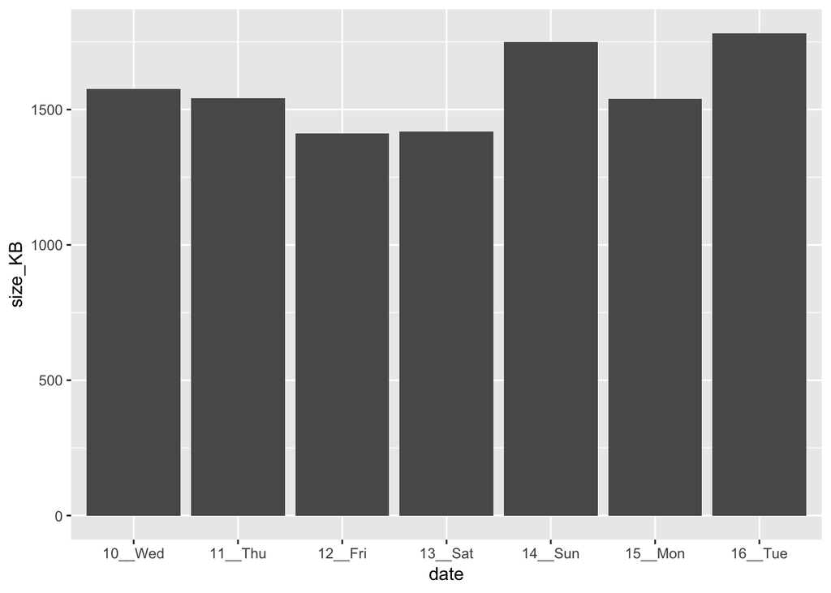

```r
filenames = as.array(paste0("./DATA/",colnames(doc.tfidf)[2:(n+1)],".txt"))
sizeResult = apply(filenames, 1, file.size) / 1024
showSize = data.frame(colnames(doc.tfidf)[2:(n+1)], sizeResult)
names(showSize) = c("date", "size_KB")

ggplot(showSize, aes(x = date, y = size_KB)) + geom_bar(stat="identity")
```

原本預期假日的發文的資料量會最大，但其實沒有。 我猜是因為我是以發文的日期為基準做檔案分割。 PTT上回文的日期可能和發文的日期錯開，所以無法看出明確差距。

### 10.wordcloud (TDM)

[figure not shown]

```r
library(wordcloud)
wc.matrix.tdm <- data.frame(
  word = TDM$d,
  freq = rowSums(TDM[,2:8])
)
par(family=("Heiti TC Light"))
row.names(wc.matrix.tdm)=NULL
wordcloud(wc.matrix.tdm$word, wc.matrix.tdm$freq, scale=c(5,0.1),max.words=50,
          random.order=FALSE, random.color=TRUE,
          rot.per=.1, colors=brewer.pal(8,"Dark2"),
          ordered.colors=FALSE,use.r.layout=FALSE,
          fixed.asp=TRUE)
```

哥布林幾乎佔據了大部分版面，除了”哥布林殺手“(本季動畫)的大部分貢獻外， 本季另一個動畫“關於我轉生變成史萊姆這檔事”可能也有小部分的貢獻。 此動畫中也有出現哥布林。 合理推斷哥布林殺手是當時討論度最高的動畫。

### 10-1. wordcloud (TF-IDF)

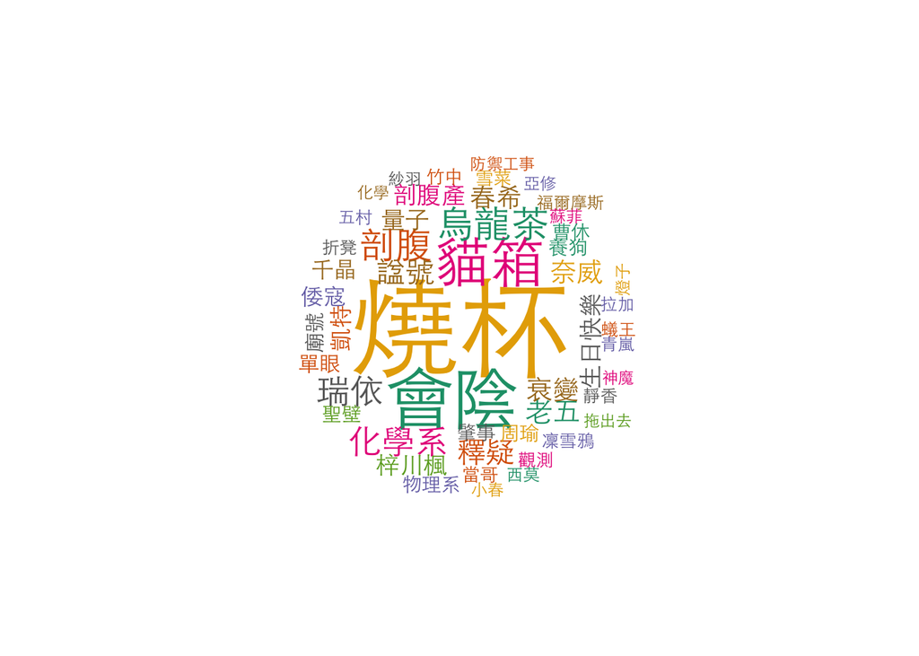

```r
wc.matrix.tfidf <- data.frame(
  word = doc.tfidf$d,
  freq = rowSums(doc.tfidf[,2:8])
)
par(family=("Heiti TC Light"))
row.names(wc.matrix.tfidf)=NULL
wordcloud(wc.matrix.tfidf$word, wc.matrix.tfidf$freq, scale=c(5,0.1),max.words=50,
          random.order=FALSE, random.color=TRUE,
          rot.per=.1, colors=brewer.pal(8,"Dark2"),
          ordered.colors=FALSE,use.r.layout=FALSE,
          fixed.asp=TRUE)
```

稍微討論文字雲中佔較大面積的詞彙

1.燒杯、化學系 前面提過的文章“化學系會不會在實驗室用燒杯煮咖啡”。 將其歸類為”青春豬頭“。

2.貓箱 https://www.ptt.cc/bbs/C_Chat/M.1539243479.A.09B.html 此貓箱意指著名的思想實驗–薛丁格的貓。一樣是”青春豬頭“中所提及。

3.會陰 前面提過的安價文章。由”哥布林殺手“的安價文所帶起。

4.剖腹 https://www.ptt.cc/bbs/C_Chat/M.1539136998.A.A6A.html 出現的原因應該是此篇轉貼新聞的文章，內容是”光之美少女“動畫提及剖腹產。 在此篇文章中不斷出現剖腹這個關鍵字。

5.烏龍茶 https://www.ptt.cc/bbs/C_Chat/M.1539439827.A.187.html 出現的原因又是哥布林殺手的安價，但烏龍茶的梗是出自上一季的動畫“碧藍之海”。

剩下的一些大致歸類一下

1.青春豬頭(本季) 梓川楓、量子、觀測、衰變

2.哥布林殺手(本季) 釋疑(文章標題：哥殺世界觀常見矛盾整理釋疑)、 聖壁、倭寇(出自：哥殺世界觀常見矛盾整理釋疑)

3.終將成為你(本季) 燈子

4.東離劍遊紀(本季) 凜雪鴉

5.bananafish(跨季) 亞修

6.獵人HunterXHunter 老五(應為莫老五)、凱特

7.哈利波特 西莫、奈威

8.殺戮天使 瑞依

9.白色相簿2 春希、千晶、雪菜

10.taritari 紗羽

### 11.每日的詞語出現次數(use TDM)

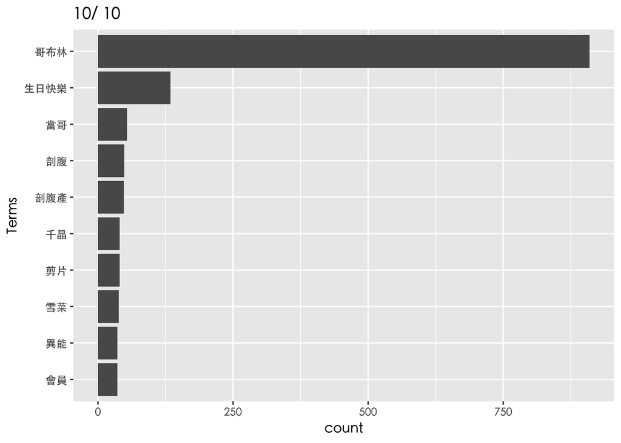

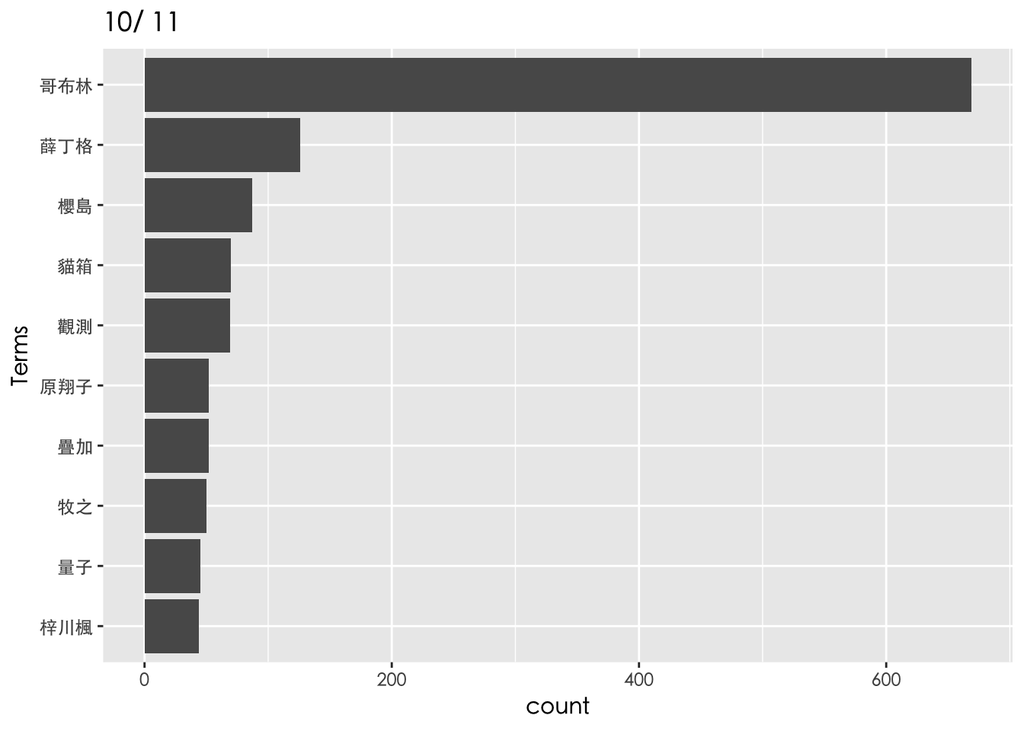

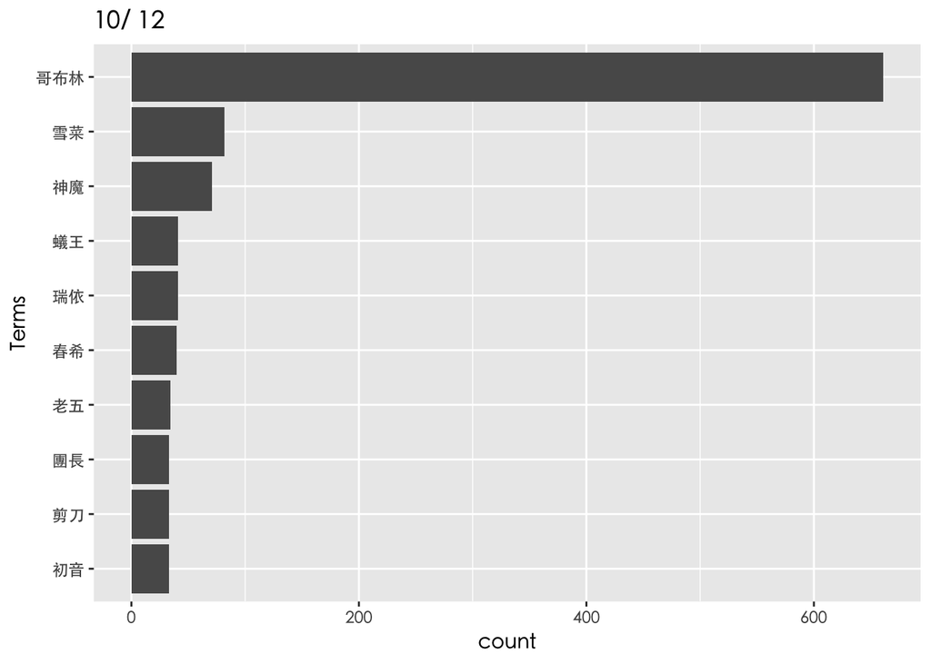

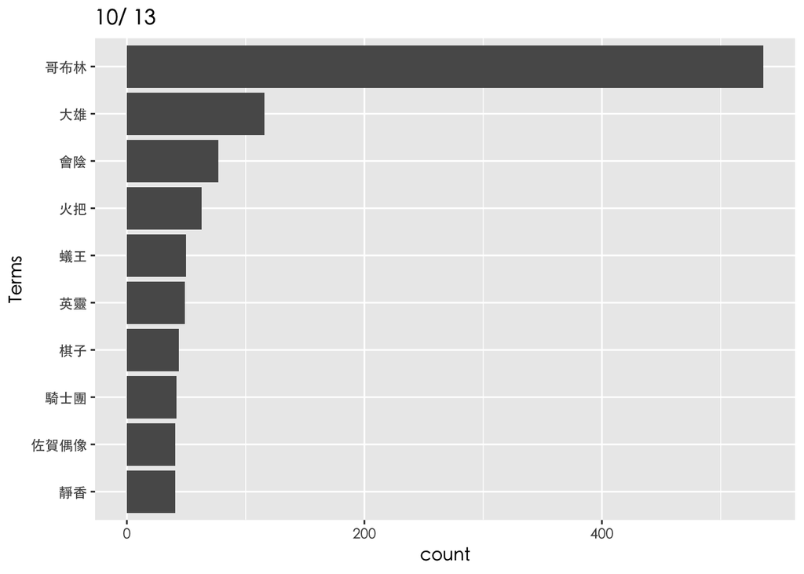

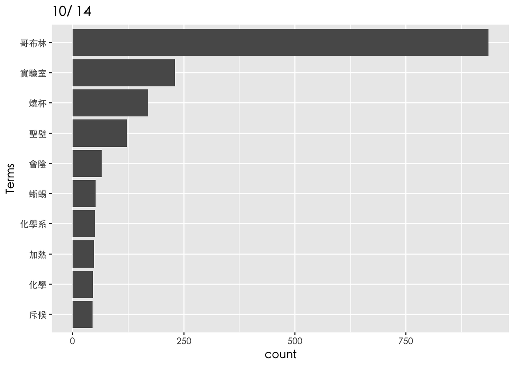

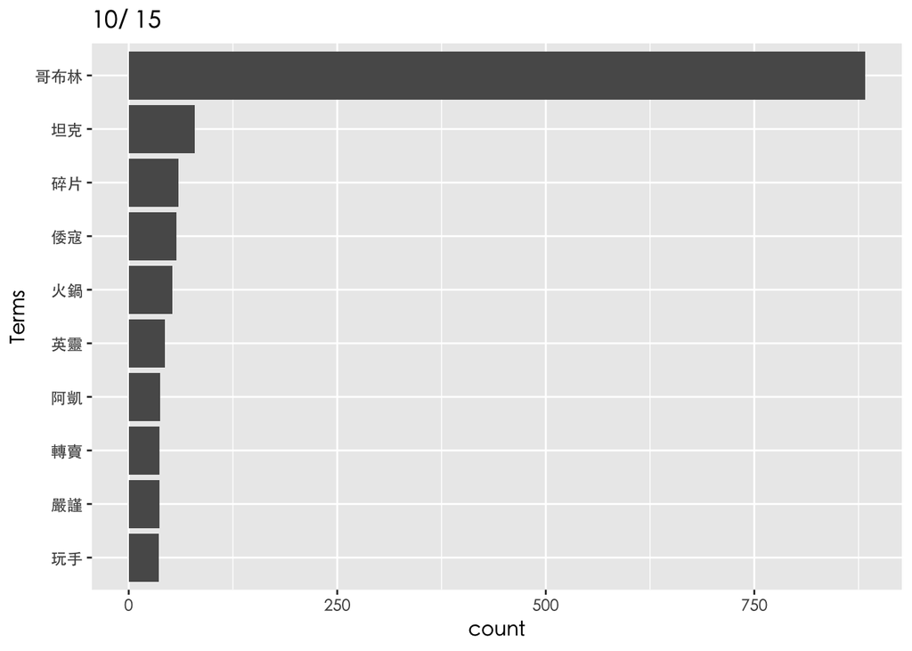

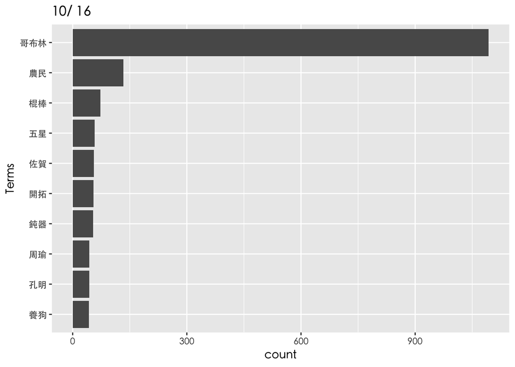

```r
for (i in c(2:8)){
  top10ID = head(order(TDM[, i], decreasing = TRUE), 10)
  nn2 = data.frame(count = TDM[top10ID,i], names = TDM[top10ID,"d"])
  print(
  ggplot(nn2, aes(reorder(names,count), count)) +
  geom_bar(stat = "identity")  + coord_flip()+
  xlab("Terms") + ylab("count") +
  ggtitle(paste("10/", i + 8))+
  theme(text = element_text(family = "黑體-繁 中黑"))
  )
}
```

這邊比較有趣的地方是10/11的圖表，除了第一名的哥布林外， 其他的都是有關“青春豬頭”的詞彙。而“青春豬頭”的首播時間是10/4的凌晨。 第二集播出的時間是10/11號的凌晨，在播映當天的討論度也最高。

### 12 PCA (日子之間)

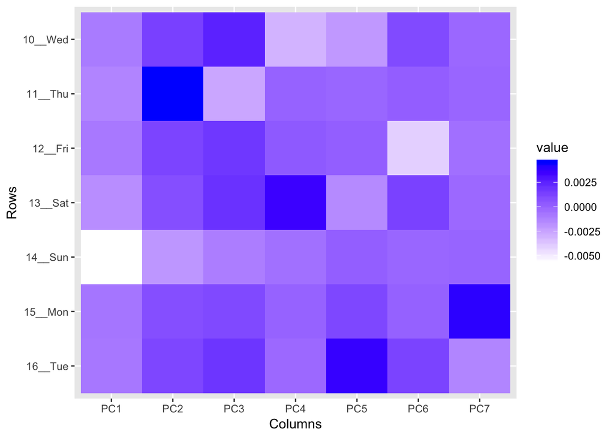

```r
library(ggfortify)
word.doc.tfidf <- subset(doc.tfidf,select = -d)
row.names(word.doc.tfidf) <- doc.tfidf$d
pcs.date <- prcomp(t(word.doc.tfidf), center = F, scale = F)
autoplot(pcs.date$x,data = newdoc, shape = FALSE, label.size = 3)
```

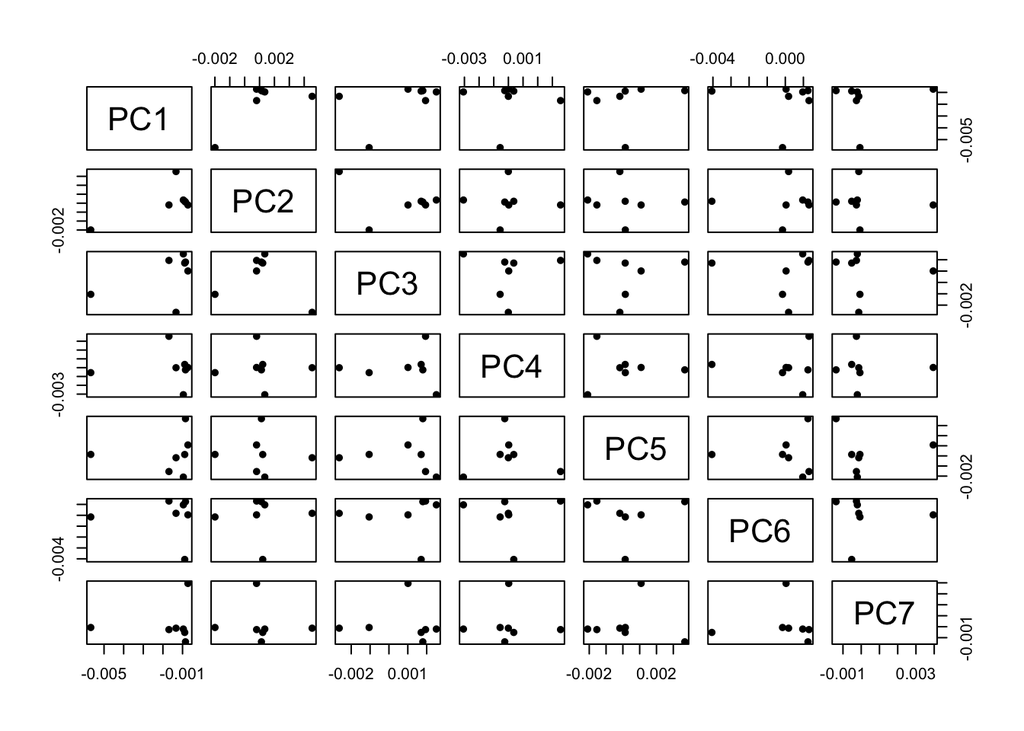

```r
princomp.date <- data.frame(pcs.date$x[,1:7])
plot(princomp.date, pch = 19, cex = 0.8)
```

### 13.PCA & K-means (日子之間的關聯性)

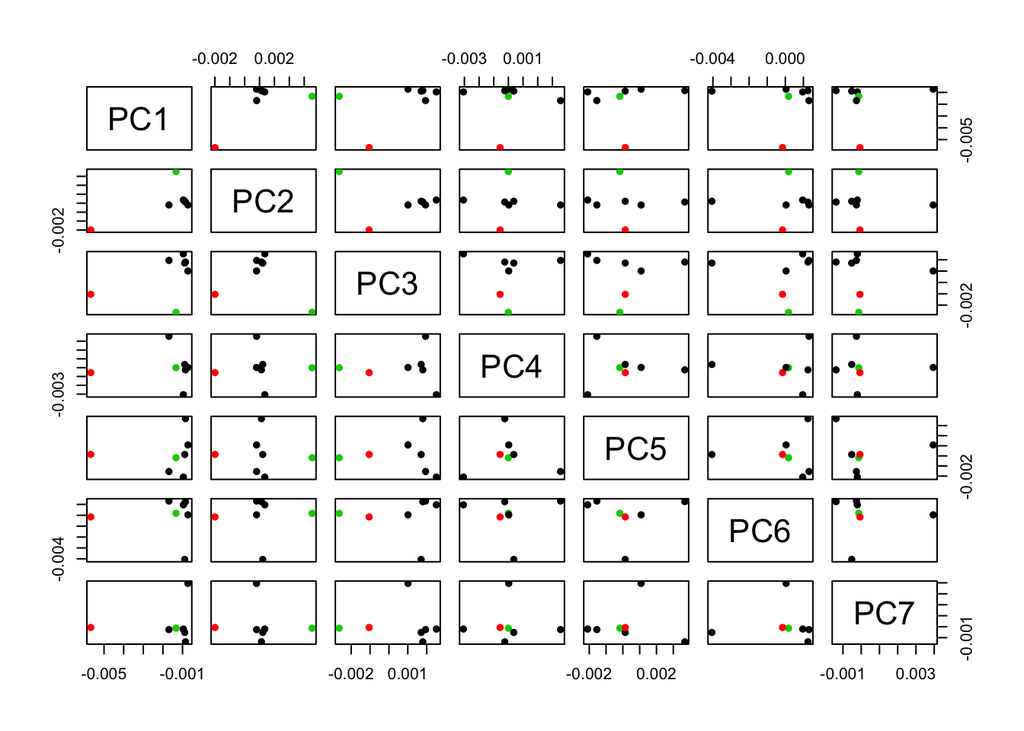

```r
k.date <- 3
km.date <- kmeans(princomp.date,centers = k.date,nstart=25, iter.max=1000)
plot(princomp.date, col=km.date$cluster, pch=16)
```

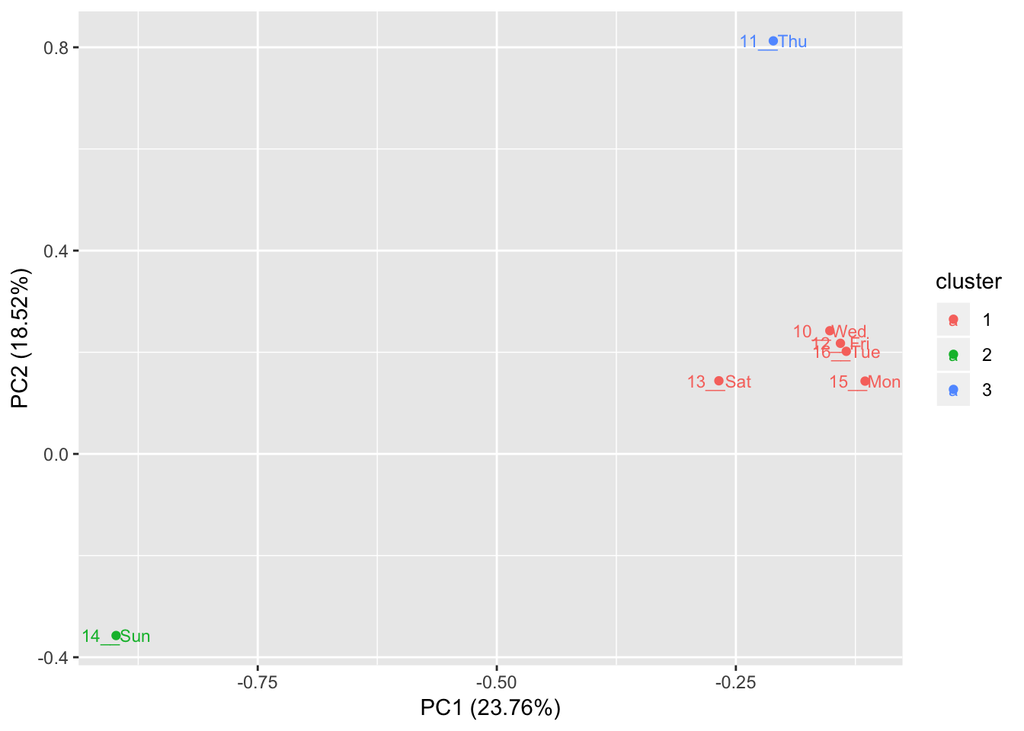

```r
autoplot(km.date, data = pcs.date, label = TRUE, label.size = 3)
```

前面提過10/11號但“青春豬頭”第二集播出當天引起討論。 10/14就是前面提過的實驗室煮咖啡文章的發文日期。

最後，我想這季的開局討論度最高的就是“哥布林殺手”了，其次是“青春豬頭”。令我意外的是“魔禁”和“刀劍”這兩個有名氣的續作竟然沒有出現。